# REACTOR_vignette_simData

Markus & Sini

2025-06-12

## Simulating data for analysis

In this vignette we will be simulating data that resembles the data you would use in your REACTOR analysis and give you a step by step guide on how to use the REACTOR package for your analysis!

Let’s start by simulating data that resembles the data from SCENIC’s [1] binarize()-function, which is just a matrix consisting of binary values. The data matrix should also contain a column that is used to identify the single-cell sample the values come from (this should also be found in the SCENIC output by default).

```r
# Single cell sample identifiers for 2 cases, 2 controls. 10 single cell samples each
cellID <- c("Covid-1-1","Covid-1-2","Covid-1-3","Covid-1-4","Covid-1-5", "Covid-1-6","Covid-1-7","Covid-1-8","Covid-1-9","Covid-1-10",
            "Covid-2-1","Covid-2-2","Covid-2-3","Covid-2-4","Covid-2-5", "Covid-2-6","Covid-2-7","Covid-2-8","Covid-2-9","Covid-2-10",
          "Healthy-1-1","Healthy-1-2","Healthy-1-3","Healthy-1-4","Healthy-1-5", "Healthy-1-6","Healthy-1-7","Healthy-1-8","Healthy-1-9","Healthy-1-10",
                    "Healthy-2-1","Healthy-2-2","Healthy-2-3","Healthy-2-4","Healthy-2-5", "Healthy-2-6","Healthy-2-7","Healthy-2-8","Healthy-2-9","Healthy-2-10")

# Lets also name a few regulons our single cell experiments might have found and add "CellID" to the beginning of this list to get the final column names for our matrix.
colNames <- c("CellID","NFIL3", "MAFB", "MYCN", "FOXK2", "PPARG", "STAT2", "JUNB", "JUND", "RELB", "ETV1")

# Now simulating the binary matrix
set.seed(1234)
binary_matrix <- matrix(sample(0:1, 40 * 10, replace = TRUE), nrow = 40, ncol = 10)
# Lets add the cell identifier column we made earlier and set the column names
binary_matrix <- cbind.data.frame(cellID, binary_matrix)
colnames(binary_matrix) <- colNames
# Lets see what our matrix should look like
head(binary_matrix)
```

```
##      CellID NFIL3 MAFB MYCN FOXK2 PPARG STAT2 JUNB JUND RELB ETV1
## 1 Covid-1-1     1    1    0     0     0     1    0    0    0    0
## 2 Covid-1-2     1    0    1     1     0     0    1    1    1    1
## 3 Covid-1-3     1    1    0     1     0     1    0    1    1    1
## 4 Covid-1-4     1    1    1     0     1     0    0    0    1    0
## 5 Covid-1-5     0    1    0     1     1     0    1    0    1    1
## 6 Covid-1-6     1    0    1     0     1     0    0    0    1    0
```

Now let’s simulate the clustering our e.g. Coralysis or SEURAT analysis might have made for us:

```r
# Lets use the single cell sample identifiers we made earlier and assign them some cell-type clusters
cellTypeClusters <- rep(c("CD 14 Monocyte", "CD 16 Monocyte", "CD8m T", "NK"), 10)
clustering <- cbind.data.frame(cellID, cellTypeClusters)
# This is what our clustering dataframe should look like
head(clustering)
```

```
##      cellID cellTypeClusters
## 1 Covid-1-1   CD 14 Monocyte
## 2 Covid-1-2   CD 16 Monocyte
## 3 Covid-1-3           CD8m T
## 4 Covid-1-4               NK
## 5 Covid-1-5   CD 14 Monocyte
## 6 Covid-1-6   CD 16 Monocyte
```

And let’s finally simulate the studyDesign table we should also have in order to run REACTOR analysis:

```r
# Donors based on the cellIDs we made earlier
donor <- c(rep("Covid1",10), rep("Covid2",10), rep("Healthy1",10), rep("Healthy2",10))
# Status of the samples
status <- c(rep("COVID",20), rep("Healthy",20))
# Other clinical information that could be available
sex <- c(rep("M",40))
admission <- c(rep("ICU",40))

# Combine into study design table
studyDesign <- cbind.data.frame(cellID, donor, status, sex,  admission)
# This is what your study design should roughly look like. It should contain the information from which donor the sample came from and their status.
head(studyDesign)
```

```
##      cellID  donor status sex admission
## 1 Covid-1-1 Covid1  COVID   M       ICU
## 2 Covid-1-2 Covid1  COVID   M       ICU
## 3 Covid-1-3 Covid1  COVID   M       ICU
## 4 Covid-1-4 Covid1  COVID   M       ICU
## 5 Covid-1-5 Covid1  COVID   M       ICU
## 6 Covid-1-6 Covid1  COVID   M       ICU
```

## Running REACTOR analysis with our newly simulated data

Now that we have some data to work with we can start running the REACTOR analysis. The first step in the REACTOR workflow is to create the activity matrix for the differential activity analysis. This can be done using the REACTOR processData-function.

### Processing the input data

The parameters required for the analysis are as follows:

| Parameter | Explanation | Value to be used in this vignette |
| --- | --- | --- |
| minCells | minimum number of cells present in a cell-type cluster within a donor | We will use 0 here as the simulated dataset is rather small |
| RBM | Regulon Binary Matrix. This is produced by SCENIC’s binarize-function! (1st column should represent the single cell sample IDs) | The binary_matrix we created earlier |
| Study Design | Study design dataframe. Should contain information (as columns) from which sample and which condition the single cell sample came and the 1st column should represent the single cell sample IDs | The studyDesign dataframe we created earlier |
| Clustering | Clustering dataframe (1st column should represent the single cell sample IDs) | The clustering dataframe we created earlier |
| cluster_cName | Column name of the clustering to use from the Clustering dataframe | “cellTypeClusters” |
| condition_cName | Name of the column of conditions to be contrasted from the StudyDesign dataframe (i.e COVID or Healthy) | “status” |
| sample_cName | Name of the sample column from the StudyDesign dataframe | “donor” |

```r
# Please ensure that the first column of each of the input data matrices represents the single-cell sample ID so we can join them!


sample_cname      = "donor"
cluster_cname     = "cellTypeClusters"
condition_cname   = "status"

minCells = 0

# processData returns a list that contains the processed data at index 1 and
# RegulonActivity dataframe at index 2. The regulonActivity dataframe can be
# viewed to fine tune the minCells parameter for future runs.
data_out <- REACTOR::processData(minCells = minCells, RBM = binary_matrix,
StudyDesign = studyDesign, Clustering = clustering,
condition_cName = condition_cname, sample_cName = sample_cname,
cluster_cName = cluster_cname)
```

```r
# Data in long format (required for the differental activity analysis)
long_data <- data_out[[1]]
# Data in wide format, can be used to i.e. fine tune the minCells parameter or create an activity heatmap
regulonActivity <- data_out[[2]]

head(long_data)
```

```
##                           Covid1    Covid2  Healthy1  Healthy2
## CD 14 Monocyte | NFIL3  33.33333 100.00000 100.00000   0.00000
## CD 14 Monocyte | MAFB   66.66667  50.00000  33.33333  50.00000
## CD 14 Monocyte | MYCN   33.33333  50.00000  33.33333 100.00000
## CD 14 Monocyte | FOXK2  66.66667 100.00000  33.33333  50.00000
## CD 14 Monocyte | PPARG  33.33333  50.00000  33.33333  50.00000
## CD 14 Monocyte | STAT2  66.66667 100.00000  33.33333   0.00000
```

### Running differential activity analysis

Now that we have done some data pre-processing we can run the differential activity analysis using the differentialActivityAnalysis-function! REACTOR uses ROTS [2] to conduct the analysis.

The input parameters are as follows:

| Parameter | Explanation | Value to be used in this vignette |
| --- | --- | --- |
| data | Dataframe containing the proportional counts of binary regulon activity. This is the first output produced by the REACTOR::processData-function. | long_data dataframe we created earlier using REACTOR |
| groups | Vector specifying the experimental groups (i.e. COVID, Healthy) as integers | In this case it is c(1,1,2,2). You can check this by viewing the long_data dataframe and checking the column names and comparing them to the metadata you have |
| Max Zeros | Maximum number of zero values present in a row of the input data frame. Rows that contain more zero values than this parameter will be filtered before the ROTS analysis. | We will use the default parameter (NA) in this case as our dataset is rather small |
| … | Parameters passed onto ROTS. See [ROTS](https://www.bioconductor.org/packages/release/bioc/html/ROTS.html) | We will be setting seed to 1234 |

```r
groups <- c(rep(1,2), rep(2,2))

# Differential activity analysis using reactor
DAA_out <- REACTOR::differentialActivityAnalysis(long_data, groups, seed=1234, K=100)
```

```
## Bootstrapping samples
```

```
## Optimizing parameters
```

```
## Calculating p-values
```

```
## Calculating FDR
```

```r
# The outputs from the analysis are as follows: at index 1 you have the ROTS object and at index 2 you have simplified results table
ROTS_obj <- DAA_out[[1]]
ROTS_results <- DAA_out[[2]]

head(ROTS_results)
```

```
##                           Covid1    Covid2 Healthy1 Healthy2         d
## CD 14 Monocyte | FOXK2  66.66667 100.00000 33.33333 50.00000 -2.236068
## CD 14 Monocyte | STAT2  66.66667 100.00000 33.33333  0.00000 -2.828428
## CD 16 Monocyte | STAT2   0.00000   0.00000 66.66667 50.00000  6.999999
## CD 16 Monocyte | RELB   66.66667 100.00000 33.33333 50.00000 -2.236068
## NK | MYCN              100.00000  66.66667 50.00000 33.33333 -2.236068
## CD 14 Monocyte | MAFB   66.66667  50.00000 33.33333 50.00000 -1.414214
##                                p       fdr        fc
## CD 14 Monocyte | FOXK2 0.1327375 0.6000000  41.66667
## CD 14 Monocyte | STAT2 0.0742625 0.6000000  66.66667
## CD 16 Monocyte | STAT2 0.0334375 0.6000000 -58.33333
## CD 16 Monocyte | RELB  0.1327375 0.6000000  41.66667
## NK | MYCN              0.1327375 0.6000000  41.66667
## CD 14 Monocyte | MAFB  0.2989125 0.8181818  16.66667
```

Based on this analysis we have one significant regulon-celltype combination based on p-value 0.05 cutoff (CD16 Monocyte STAT2). The FDR values are not significant due to the nature in which we simulated the data and the dataset being rather small. With the ROTS object you can easily do some plotting. Let’s explore a few options (more can be found in [ROTS](https://www.bioconductor.org/packages/release/bioc/html/ROTS.html) documentation)

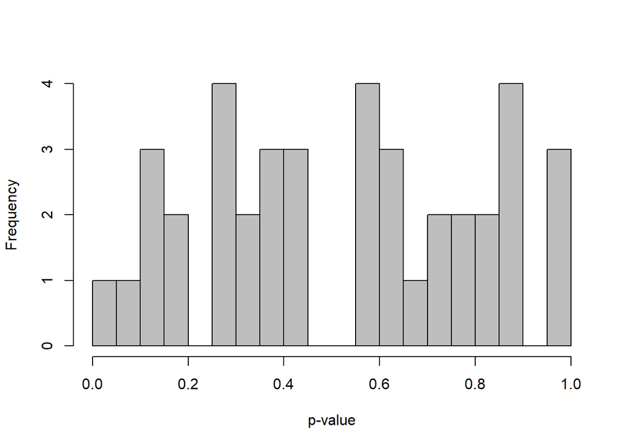

```r
plot(ROTS_obj, type="pvalue")
```

[figure not shown]

```r
plot(ROTS_obj, type="reproducibility", xlab="Fold Change")
```

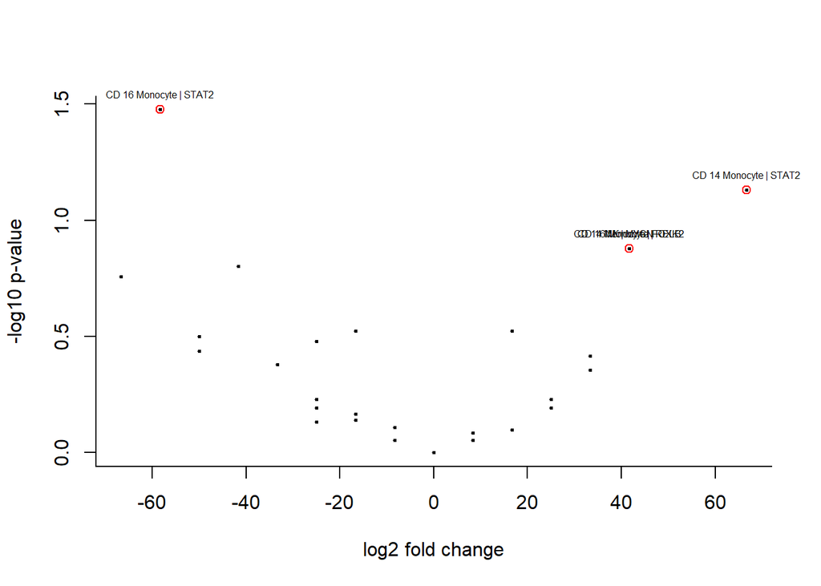

```r
plot(ROTS_obj, type="volcano", fdr=0.61, labels = T)
```

## References

[1] B. Van de Sande et al., “A scalable SCENIC workflow for single-cell gene regulatory network analysis,” Nat. Protoc., vol. 15, no. 7, Art. no. 7, Jul. 2020, doi: 10.1038/s41596-020-0336-2.

[2] T. Suomi, F. Seyednasrollah, M. K. Jaakkola, T. Faux, and L. L. Elo, “ROTS: An R package for reproducibility-optimized statistical testing,” PLOS Comput. Biol., vol. 13, no. 5, p. e1005562, May 2017, doi: 10.1371/journal.pcbi.1005562.